# Metro - Case Study

8/24/2018

## Contents

- EDA
- Variables
- Model
- Results
- Conclusion

## EDA

output variable: volume_sold.

[interactive chart not shown]

## EDA

[interactive chart not shown]

## EDA

After modifications of variable volume_sold.

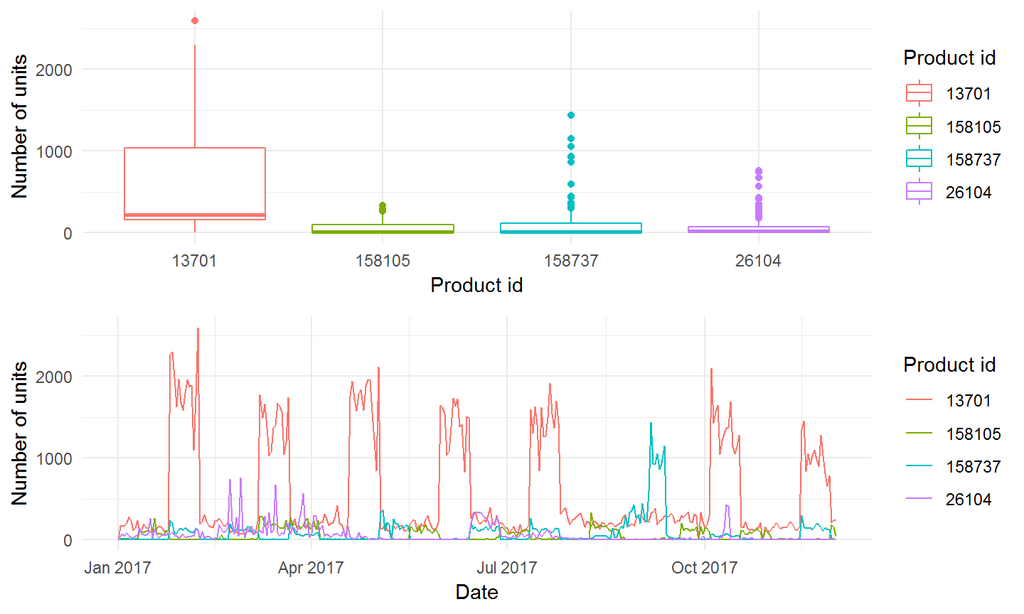

## EDA

Let's consider that one product makes more than 70% of the total amount of volume, as well as the different shape of its time series.

| product_id | pct_volume | pct_zeroes |
| --- | --- | --- |
| 13701 | 74.42 | 1.52 |
| 26104 | 7.84 | 42.55 |
| 158105 | 6.84 | 3.08 |
| 158737 | 10.90 | 2.76 |

## Variables

- volume_sold: outcome variable
- revenue: depends on volume sold
- cost: depends on volume sold
- stock_level: consider in the model
- retail_price: consider in the model
- mpdm1: consider in the model

The model was built considering the direct effects on sales (volume sold) of a set of variables.

## Variables

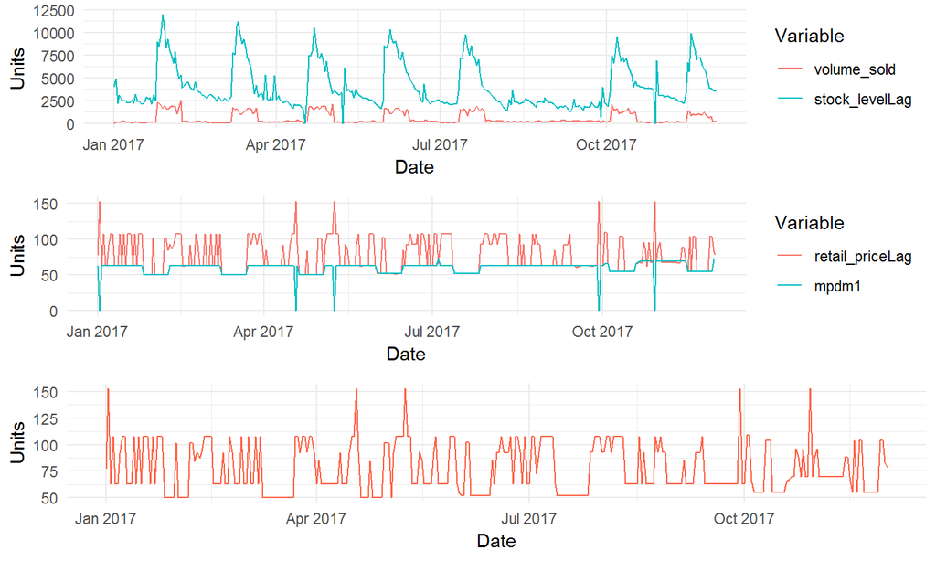

## Model

-Weekly aggregation with lags for stock and price variables. Product id 13701.

[interactive chart not shown]

## Model

-Weekly aggregation with lags for stock and price variables. Product id 26104 and 158105.

[interactive chart not shown]

## Model

-Weekly aggregation with lags for stock and price variables. Product id 158737.

[interactive chart not shown]

## Model

Linear regression with ARIMA errors for product id 13701.

```
## Series: log(ser.model + 1)
## Regression with ARIMA(6,0,0) errors
##
## Coefficients:
##          ar1      ar2      ar3     ar4      ar5     ar6  intercept
##       0.7210  -0.1532  -0.3518  0.4070  -0.2118  0.0808    -6.1982
## s.e.  0.1549   0.1793   0.1740  0.1816   0.1993  0.1625     1.6713
##         price   stock    vwm1
##       -0.1399  1.0788  0.4735
## s.e.   0.1867  0.1035  0.0812
##
## sigma^2 estimated as 0.07959:  log likelihood=-2.13
## AIC=26.26   AICc=33.8   BIC=46.61
```

## Model

Linear regression with ARIMA errors for product id 26104 and 158105.

```
## Series: log(ser.model + 1)
## Regression with ARIMA(1,0,0) errors
##
## Coefficients:
##           ar1  intercept    price   stock    vwm1
##       -0.0661     16.947  -3.1049  0.1029  0.6983
## s.e.   0.1571      5.152   0.9126  0.1015  0.0981
##
## sigma^2 estimated as 0.2833:  log likelihood=-34.41
## AIC=80.81   AICc=82.91   BIC=91.91
```

## Model

Linear regression with ARIMA errors for product id 158737.

```
## Series: log(ser.model + 1)
## Regression with ARIMA(1,0,0) errors
##
## Coefficients:
##          ar1  intercept    price   stock    vwm1
##       0.5337     2.5247  -2.3063  1.1512  0.8047
## s.e.  0.2839    11.4254   0.9785  0.6171  0.1561
##
## sigma^2 estimated as 0.4393:  log likelihood=-44.88
## AIC=101.76   AICc=103.86   BIC=112.86
```

## Results

Fit and residuals for product id 13701.

[interactive chart not shown]

## Results

Fit and residuals for product id 26104 and 158105.

[interactive chart not shown]

## Results

Fit and residuals for product id 158737.

[interactive chart not shown]

## Results

|  | Product id | MAPE |
| --- | --- | --- |
| acc.13701 | 13701 | 20.78 |
| acc.26104 | 26104 | 48.02 |
| acc.158737 | 158737 | 59.83 |